# Conjugation of Permutations

### **NOTES ON STATISTICS, PROBABILITY and MATHEMATICS**

#### How to read out permutations:

From [here](https://youtu.be/6sOAYTQnKLM):

The $S_8$ permutation

$$(1\; 8 \; 7 \; 2)$$

can be expressed in stack form as position $\color{red} 1$ will end up in position $\color{magenta} 8,$ while $\color{magenta} 8$ will end up in position $\color{blue}7$ and so on:

$$\begin{matrix}
\color{red}1 \quad \color{orange}2 \quad 3 \quad 4 \quad 5 \quad 6 \quad
\color{blue} 7 \quad \color{magenta}8 \\
\downarrow \quad \downarrow \quad \downarrow \quad \downarrow \quad
\downarrow \quad \downarrow \quad \downarrow \quad \downarrow \\
\color{orange} 2 \quad \color{blue}7 \quad 3 \quad 4 \quad 5 \quad 6
\quad \color{magenta} 8 \quad \color{red} 1
\end{matrix}$$

This is the way that Matthew Salomone teaches it in [here](https://youtu.be/6sOAYTQnKLM?t=295), which could be thought of as “trading chairs; keeping your number.”

However, another (and more intuitive) way of reading it would be: $\color{red}1$ goes to $\color{magenta}8,$ while $\color{magenta} 8$ goes to $\color{blue}7$ and so on:

$$\begin{matrix}
\color{red}1 \quad \color{orange}2 \quad 3 \quad 4 \quad 5 \quad 6
\quad \color{blue}7 \quad \color{magenta}8 \\
\downarrow \quad \downarrow \quad \downarrow \quad \downarrow \quad
\downarrow \quad \downarrow \quad \downarrow \quad \downarrow \\
\color{magenta} 8 \quad \color{red}1 \quad 3 \quad 4 \quad 5 \quad 6
\quad \color{orange}2 \quad \color{blue} 7
\end{matrix}$$

It could be thought of as “trading numbers; keeping your chair.”

Both result in the same cycle expression.

#### Simplifying permutations:

Two permutations $(1\; 3 \; 2 \; 5) \, (1\; 8 \; 7 \; 2)$ can be simplified (using the trading chairs stack notation) as in [here](https://youtu.be/6sOAYTQnKLM?t=272):

$$(1\; 8 \; 7 \; 2) = \begin{pmatrix}
1 \quad 2 \quad 3 \quad 4 \quad 5 \quad 6 \quad 7 \quad 8 \\
\color{red}{2 \quad 7 \quad 3 \quad 4 \quad 5 \quad 6 \quad 8 \quad 1 }
\end{pmatrix}$$

$$(1\; 3 \; 2 \; 5) = \begin{pmatrix}
1 \quad 2 \quad 3 \quad 4 \quad 5 \quad 6 \quad 7 \quad 8 \\
5 \quad 3 \quad 1 \quad 4 \quad 2 \quad 6 \quad 7 \quad 8
\end{pmatrix}$$

The idea is to use the result of the first permutation as the input of the second, although this step is omitted, or struck out in the final expression:

$$(1\; 3 \; 2 \; 5)\,(1\; 8 \; 7 \; 2) =
\begin{pmatrix}
1 \quad 2 \quad 3 \quad 4 \quad 5 \quad 6 \quad 7 \quad 8 \\
\text{trade seats = first permutation on the right:}\\
\color{red}{2 \quad 7 \quad 3 \quad 4 \quad 5 \quad 6 \quad 8 \quad 1
} \\
\text{pass on the result to the input for the second permutation:}\\
1_{\color{red}{2}} \quad 2_{\color{red}{7}} \quad 3_{\color{red}{3}}
\quad 4_{\color{red}{4}} \quad 5_{\color{red}{5}} \quad
6_{\color{red}{6}} \quad 7_{\color{red}{8}} \quad 8_{\color{red}{1}} \\
\text{trade seat = second permutation:}\\
5_{\color{red}{5}} \quad 3_{\color{red}{3}} \quad
1_{\color{red}{2}}\quad 4_{\color{red}{4}}\quad
2_{\color{red}{7}} \quad 6_{\color{red}{6}} \quad 7_{\color{red}{8}}
\quad 8_{\color{red}{1}} \\
\text{replace the numbers in each seat with the input numbers:}\\
\color{red}{5 \quad 3 \quad 2 \quad 4 \quad 7 \quad 6 \quad 8 \quad 1 }
\end{pmatrix}$$

or

$$(1\; 3 \; 2 \; 5)\,(1\; 8 \; 7 \; 2) =
\begin{pmatrix}
1 \quad 2 \quad 3 \quad 4 \quad 5 \quad 6 \quad 7 \quad 8 \\
\color{red}{5 \quad 3 \quad 2 \quad 4 \quad 7 \quad 6 \quad 8 \quad 1 }
\end{pmatrix}$$

which in cycle notation is

$$(1\; 3 \; 2 \; 5)\,(1\; 8 \; 7 \; 2) =
(1 \; 8 \; 7 \; 5)\;(2 \; 3)$$

Using the “trading numbers; keeping seats” system we just follow the numbers down the trail:

$$(1\; 3 \; 2 \; 5)\,(1\; 8 \; 7 \; 2) =
\begin{pmatrix}
1 \quad 2 \quad 3 \quad 4 \quad 5 \quad 6 \quad 7 \quad 8 \\
\text{trade numbers = first permutation on the right:}\\
\color{red}{8 \quad 1 \quad 3 \quad 4 \quad 5 \quad 6 \quad 2 \quad 7
} \\
\text{pass on the result to the input for the second permutation}\\
\text{following the number matches - location has no info:}\\
\text{so realigning vertically the second cycle to coincide with
output:}\\
8 \quad 1 \quad 3 \quad 4 \quad 5 \quad 6 \quad 2 \quad 7 \\
\color{red}{8 \quad 3 \quad 2 \quad 4 \quad 1 \quad 6 \quad 5 \quad 7 }
\end{pmatrix}$$

or

$$(1\; 3 \; 2 \; 5)\,(1\; 8 \; 7 \; 2) =
\begin{pmatrix}
1 \quad 2 \quad 3 \quad 4 \quad 5 \quad 6 \quad 7 \quad 8 \\
\color{red}{8 \quad 3 \quad 2 \quad 4 \quad 1 \quad 6 \quad 5 \quad 7 }
\end{pmatrix}$$

which yields the same cycle notation as with the trading places system.

This is simply following the numbers vertically (no need to actually reshuffle to match them as above):

$$(1\; 3 \; 2 \; 5)\,(1\; 8 \; 7 \; 2) =
\begin{pmatrix}
\bbox[5px,border:2px solid red]1 \quad 2 \quad 3 \quad 4 \quad 5 \quad 6
\quad 7 \quad 8 \\
\color{red}{8\downarrow}\quad 2 \quad 3 \quad 4 \quad 5 \quad 6 \quad 2
\quad 7 \\
\color{red}{\rightarrow \rightarrow \rightarrow \rightarrow \rightarrow
\rightarrow \rightarrow \rightarrow \rightarrow \rightarrow}
\\
1 \quad 2 \quad 3 \quad 4 \quad 5 \quad 6 \quad 7 \color{red}{\quad
\downarrow 8} \\
3 \quad 5 \quad 2 \quad 4 \quad 1 \quad 6 \quad 7 \quad
\bbox[5px,border:2px solid red]8
\end{pmatrix}$$

#### Conjugation of permutations:

From [here](https://youtu.be/unXq_RKSy0A):

The permutation

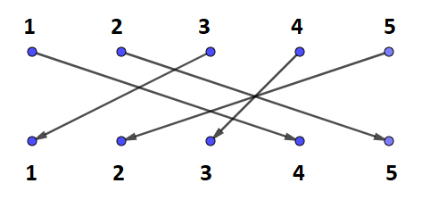

can be expressed as
$$(1 \, 4 \, 3)\;(2 \,
5)$$

in cycle notation, which visually is more clear if we rearrange the permutation graph as

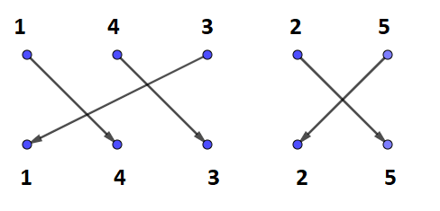

which would allow us to see at once that this permutation is up-to-relabeling identical to

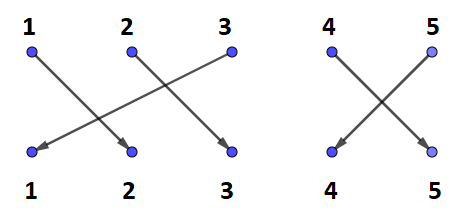

or
$$(1 \, 2 \, 3)\;(4 \, 5)$$

They both have the same cycle type, and the first permutation can be turned into the second via a re-labeling map:

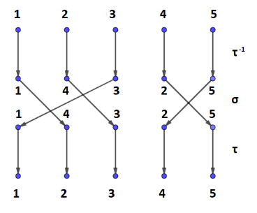

which can be expressed as

$$\tau \sigma \tau^{-1}$$

Both $\tau$ and $\sigma$ belong to the symmetric group $S_5,$ and $\tau$ could have been any other element (or permutation) in $S_5.$

The new mapping, i.e. $\tau \sigma \tau^{-1}$ will be another element of $S_5$ of the same cycle type as $\sigma,$ and the operation $\tau \sigma \tau^{-1}$ is **conjugation**.

How can we write the cycle decomposition of $\tau \sigma \tau^{-1}$ by relabeling the domain and co-domain of $\sigma$ as

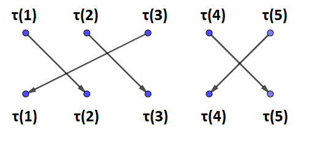

and note that since permutations are bijections writing $\tau$ or $\tau^{-1}$ makes no difference. In cycle notation, the new $\tau \sigma \tau^{-1}$ permutation would be

$$\left( \tau(1) \, \tau(2) \tau(3) \right
)\;\left (\tau(4) \, \tau(5)\right)$$

Exercise from an example [here](https://youtu.be/X63MWZIN3gM?t=2760):

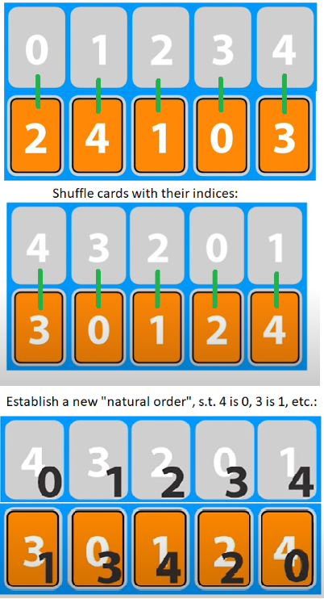

For this to be concordant with the card game on the presentation the first row (first permutation given) should be understood as $0$ moves to slot number $3$; $1$ moves to slot number $2$; $2 \to 0; \quad 3 \to 4; \quad 4 \to 1:$

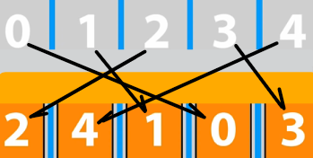

which would result in

$$\sigma =
\begin{pmatrix}
0\; 1 \; 2 \; 3 \; 4 \\
3 \; 2 \; 0 \; 4 \; 1
\end{pmatrix}$$

or in cycle notation:

$$\sigma=(0\,3\,4\,1\,2)$$

And, similarly,

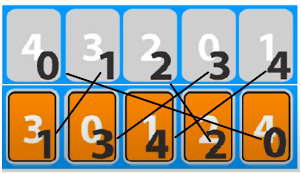

$$\tau\sigma\tau^{-1} =
\begin{pmatrix}
0\; 1 \; 2 \; 3 \; 4 \\
4 \; 0 \; 3 \; 1 \; 2
\end{pmatrix}\\$$

or in cycle notation:

$$\tau\sigma\tau^{-1}=(0\,4\,2\,3\,1)$$

Tau can be obtained by stacking up

$$\begin{bmatrix}\begin{align}\sigma=
(0\,3\,4\,1\,2)\\\tau\sigma\tau^{-1}=(0\,4\,2\,3\,1)
\end{align}\end{bmatrix}\implies
\tau =(0)\,(3\,4\,2\,1)$$

and reading the entries in cycle notation column wise. So $\tau$ is constructed in cycle form by reading $0→0, 3→4, 4→2, 1→3, 2→1,$

Here is the proof in “trading numbers stacked notation” (Wolfram Alpha style):

$$\begin{align}
\tau^{-1}=(0)\,(3\,1\,2\,4))&=
\begin{pmatrix}
0 & 1 & 2 & 3 & 4 \\
0 & 2 & 4 & 1 & 3
\end{pmatrix} \\
\sigma=(0\,3\,4\,1\,2) &= \begin{pmatrix}
0& 1 & 2 & 3 & 4 \\
3 & 2 & 0 & 4 & 1
\end{pmatrix} \\
\tau=(0)\,(3\,4\,2\,1) &=
\begin{pmatrix}
0 & 1 & 2 & 3 & 4 \\
0 & 3 & 1 & 4 & 2
\end{pmatrix} \\
\hline
\tau \sigma \tau^{-1} &=
\begin{pmatrix}
0 & 1 & 2 & 3 & 4 \\
4 & 0 & 3 & 1 & 2
\end{pmatrix}
\end{align}$$

[Home Page](http://rinterested.github.io/statistics/index.html)

**NOTE: These are tentative notes on different topics for personal use - expect mistakes and misunderstandings.**